# ACE_modelling

```r
round(exp(cbind(OR = nblone_bully_model3_compcase$coeff, confint(nblone_bully_model3_compcase))),
    3)
```

```
##                                                                    OR 2.5 %
## (Intercept)                                                     1.229 0.533
## GU_bullied_T1Bullied (GUp)                                      1.381 1.188
## anyotherAE_exceptBullying_T0_T1Other AE                         1.047 0.910
## admincgender_T0Female                                           1.903 1.661
## ethnicity5_C_T1Mixed                                            1.219 0.388
## ethnicity5_C_T1Asian                                            0.935 0.641
## ethnicity5_C_T1Black                                            1.284 0.425
## ethnicity5_C_T1Other                                            1.366 0.457
## mbqlcasep5gp_T0Employed not mat dep                             1.058 0.715
## mbqlcasep5gp_T0Employed no access to money                      0.890 0.565
## mbqlcasep5gp_T0Benefits but coping                              0.944 0.562
## mbqlcasep5gp_T0Most dep                                         1.345 0.822
## admincdobagemy_T0                                               0.986 0.973
## hhd0tothhd_T0                                                   0.979 0.951
## has_conganom_gp_T1_derivedHas congenital anomalies              1.445 1.077
## GU_AgeYears_T1                                                  1.025 0.956
## ethnicity5_C_T1Mixed:mbqlcasep5gp_T0Employed not mat dep        0.408 0.090
## ethnicity5_C_T1Asian:mbqlcasep5gp_T0Employed not mat dep        0.974 0.600
## ethnicity5_C_T1Black:mbqlcasep5gp_T0Employed not mat dep           NA    NA
## ethnicity5_C_T1Other:mbqlcasep5gp_T0Employed not mat dep        0.277 0.010
## ethnicity5_C_T1Mixed:mbqlcasep5gp_T0Employed no access to money 0.927 0.214
## ethnicity5_C_T1Asian:mbqlcasep5gp_T0Employed no access to money 1.018 0.605
## ethnicity5_C_T1Black:mbqlcasep5gp_T0Employed no access to money 1.014 0.166
## ethnicity5_C_T1Other:mbqlcasep5gp_T0Employed no access to money 0.495 0.085
## ethnicity5_C_T1Mixed:mbqlcasep5gp_T0Benefits but coping         0.274 0.039
## ethnicity5_C_T1Asian:mbqlcasep5gp_T0Benefits but coping         0.936 0.535
## ethnicity5_C_T1Black:mbqlcasep5gp_T0Benefits but coping         1.741 0.169
## ethnicity5_C_T1Other:mbqlcasep5gp_T0Benefits but coping         0.718 0.090
## ethnicity5_C_T1Mixed:mbqlcasep5gp_T0Most dep                    0.289 0.065
## ethnicity5_C_T1Asian:mbqlcasep5gp_T0Most dep                    0.685 0.385
## ethnicity5_C_T1Black:mbqlcasep5gp_T0Most dep                    0.855 0.158
## ethnicity5_C_T1Other:mbqlcasep5gp_T0Most dep                    1.156 0.228
##                                                                 97.5 %
## (Intercept)                                                      2.833
## GU_bullied_T1Bullied (GUp)                                       1.607
## anyotherAE_exceptBullying_T0_T1Other AE                          1.204
## admincgender_T0Female                                            2.181
## ethnicity5_C_T1Mixed                                             4.146
## ethnicity5_C_T1Asian                                             1.361
```

[output cut: 11 more lines]

```
## ethnicity5_C_T1Asian:mbqlcasep5gp_T0Employed not mat dep         1.584
## ethnicity5_C_T1Black:mbqlcasep5gp_T0Employed not mat dep            NA
## ethnicity5_C_T1Other:mbqlcasep5gp_T0Employed not mat dep         5.599
## ethnicity5_C_T1Mixed:mbqlcasep5gp_T0Employed no access to money  3.864
## ethnicity5_C_T1Asian:mbqlcasep5gp_T0Employed no access to money  1.714
## ethnicity5_C_T1Black:mbqlcasep5gp_T0Employed no access to money  6.235
## ethnicity5_C_T1Other:mbqlcasep5gp_T0Employed no access to money  2.645
## ethnicity5_C_T1Mixed:mbqlcasep5gp_T0Benefits but coping          1.592
## ethnicity5_C_T1Asian:mbqlcasep5gp_T0Benefits but coping          1.633
## ethnicity5_C_T1Black:mbqlcasep5gp_T0Benefits but coping         28.200
## ethnicity5_C_T1Other:mbqlcasep5gp_T0Benefits but coping          5.958
## ethnicity5_C_T1Mixed:mbqlcasep5gp_T0Most dep                     1.210
## ethnicity5_C_T1Asian:mbqlcasep5gp_T0Most dep                     1.215
## ethnicity5_C_T1Black:mbqlcasep5gp_T0Most dep                     4.879
## ethnicity5_C_T1Other:mbqlcasep5gp_T0Most dep                     6.408
```

```r
model.comparison(nblone_bully_model3_compcase, nblone_bully_model2_compcase)  ## rcads_bully_model2_compcase is better
```

```
## $statistics
##                                   aic      bic bayes.factor
## nblone_bully_model3_compcase 4514.594 4681.995  0.00000e+00
## nblone_bully_model2_compcase 4494.682 4583.614  2.30709e+21
##
## $predicted_differences
##    0%   25%   50%   75%  100%
## 0.000 0.008 0.019 0.061 1.947
```

```r
##**To use
nblone_bully_model_comp_tab <- list("Univariate model (Model 1) (Score ratio)" = nblone_bully_unadjcompcase, # then to add in for other variables
                               "Full model (Model 2) (Score ratio)" = nblone_bully_model2_compcase,
                               "Full model with interaction (Model 3) (Score ratio)" = nblone_bully_model3_compcase)

modelsummary(nblone_bully_model_comp_tab, estimate = "{estimate} [{conf.low}, {conf.high}]", statistic = NULL, exponentiate = T, coef_omit = "Intercept", coef_rename = coeff_name, gof_omit = "Log.Lik.|RMSE|F|Std.Errors")
```

|  | Univariate model (Model 1) (Score ratio) | Full model (Model 2) (Score ratio) | Full model with interaction (Model 3) (Score ratio) |
| --- | --- | --- | --- |
| Was bullied vs not bullied (GUp) | 1.352 [1.173, 1.559] | 1.389 [1.195, 1.616] | 1.381 [1.188, 1.607] |
| anyotherAE_exceptBullying_T0_T1Other AE |  | 1.036 [0.901, 1.191] | 1.047 [0.910, 1.204] |
| Sex at birth (Female vs Male) |  | 1.899 [1.659, 2.176] | 1.903 [1.661, 2.181] |
| Mixed vs White adolescents |  | 0.634 [0.413, 0.973] | 1.219 [0.388, 4.146] |
| Asian vs White adolescents |  | 0.873 [0.727, 1.048] | 0.935 [0.641, 1.361] |
| Black vs White adolescents |  | 1.349 [0.694, 2.725] | 1.284 [0.425, 4.277] |
| Other vs White adolescents |  | 1.115 [0.607, 2.075] | 1.366 [0.457, 4.220] |
| Mother employed, not materially deprived vs least deprived and most educated (at baseline) |  | 0.996 [0.797, 1.246] | 1.058 [0.715, 1.562] |
| Mother employed, no access to money vs least deprived and most educated (at baseline) |  | 0.898 [0.723, 1.115] | 0.890 [0.565, 1.401] |
| Mother received benefits and not materially deprived vs least deprived and most educated (at baseline) |  | 0.881 [0.725, 1.071] | 0.944 [0.562, 1.591] |
| Mother most economically deprived vs least deprived and most educated (at baseline) |  | 1.007 [0.790, 1.284] | 1.345 [0.822, 2.211] |
| Mother's age (baseline) |  | 0.985 [0.972, 0.998] | 0.986 [0.973, 0.999] |
| Number of people in mother's household (baseline) |  | 0.977 [0.949, 1.006] | 0.979 [0.951, 1.008] |
| Has congenital anomalies vs no anomalies |  | 1.459 [1.091, 1.959] | 1.445 [1.077, 1.946] |
| Age at GUp survey |  | 1.020 [0.953, 1.093] | 1.025 [0.956, 1.098] |
| Mixed vs White adolescents:Mother employed, not materially deprived vs least deprived and most educated (at baseline) |  |  | 0.408 [0.090, 1.723] |
| Asian vs White adolescents:Mother employed, not materially deprived vs least deprived and most educated (at baseline) |  |  | 0.974 [0.600, 1.584] |
| Other vs White adolescents:Mother employed, not materially deprived vs least deprived and most educated (at baseline) |  |  | 0.277 [0.010, 5.599] |
| Mixed vs White adolescents:Mother employed, no access to money vs least deprived and most educated (at baseline) |  |  | 0.927 [0.214, 3.864] |
| Asian vs White adolescents:Mother employed, no access to money vs least deprived and most educated (at baseline) |  |  | 1.018 [0.605, 1.714] |
| Black vs White adolescents:Mother employed, no access to money vs least deprived and most educated (at baseline) |  |  | 1.014 [0.166, 6.235] |
| Other vs White adolescents:Mother employed, no access to money vs least deprived and most educated (at baseline) |  |  | 0.495 [0.085, 2.645] |
| Mixed vs White adolescents:Mother received benefits and not materially deprived vs least deprived and most educated (at baseline) |  |  | 0.274 [0.039, 1.592] |
| Asian vs White adolescents:Mother received benefits and not materially deprived vs least deprived and most educated (at baseline) |  |  | 0.936 [0.535, 1.633] |
| Black vs White adolescents:Mother received benefits and not materially deprived vs least deprived and most educated (at baseline) |  |  | 1.741 [0.169, 28.200] |
| Other vs White adolescents:Mother received benefits and not materially deprived vs least deprived and most educated (at baseline) |  |  | 0.718 [0.090, 5.958] |
| Mixed vs White adolescents:Mother most economically deprived vs least deprived and most educated (at baseline) |  |  | 0.289 [0.065, 1.210] |
| Asian vs White adolescents:Mother most economically deprived vs least deprived and most educated (at baseline) |  |  | 0.685 [0.385, 1.215] |
| Black vs White adolescents:Mother most economically deprived vs least deprived and most educated (at baseline) |  |  | 0.855 [0.158, 4.879] |
| Other vs White adolescents:Mother most economically deprived vs least deprived and most educated (at baseline) |  |  | 1.156 [0.228, 6.408] |
| Num.Obs. | 1671 | 1382 | 1382 |
| AIC | 5565.9 | 4494.7 | 4514.6 |
| BIC | 5582.1 | 4583.6 | 4682.0 |

```r
#to save
#modelsummary(nblone_bully_model_comp_tab, estimate = "{estimate} [{conf.low}, {conf.high}]", statistic = NULL, exponentiate = T, coef_omit = "Intercept", coef_rename = coeff_name, gof_omit = "Log.Lik.|RMSE|F|Std.Errors", output = "nblone_bully_model_comp_tab.docx")

rm(nblone_bully_model_comp_tab)
rm(nblone_bully_unadjcompcase)
rm(nblone_bully_model3_compcase)
```

```r
# for nblone_bully_model2_compcase <- glm.nb(loneliness0to6 ~ GU_bullied_T1 + anyotherAE_exceptBullying_T0_T1  + admincgender_T0 + ethnicity5_C_T1 + mbqlcasep5gp_T0 + admincdobagemy_T0 + hhd0tothhd_T0 + has_conganom_gp_T1_derived + GU_AgeYears_T1, data = df2662_complcase)

# lone_bully_poolmodel1
lone_bully_poolmodel1 <- with(mice2662, glm.nb(loneliness0to6 ~ GU_bullied_T1))
lone_bully_pool1 <- pool(lone_bully_poolmodel1)
summary(lone_bully_pool1, conf.int=T, exponentiate=T) %>% kable()
```

| term | estimate | std.error | statistic | df | p.value | 2.5 % | 97.5 % | conf.low | conf.high |
| --- | --- | --- | --- | --- | --- | --- | --- | --- | --- |
| (Intercept) | 1.172641 | 0.0369894 | 4.305529 | 823.2863 | 0.0000187 | 1.090520 | 1.260947 | 1.090520 | 1.260947 |
| GU_bullied_T1Bullied (GUp) | 1.272851 | 0.0714670 | 3.375809 | 981.4475 | 0.0007648 | 1.106291 | 1.464486 | 1.106291 | 1.464486 |

```r
# save as nblone_bully_emmeans.csv for nblone_bully_emmeans_plot
emmeans(lone_bully_poolmodel1, revpairwise ~ GU_bullied_T1, type="response", infer =T)
```

```
## $emmeans
##  GU_bullied_T1     response     SE   df lower.CL upper.CL null t.ratio p.value
##  Not Bullied (GUp)     1.17 0.0434 1335     1.09     1.26    1   4.306  <.0001
##  Bullied (GUp)         1.49 0.0920 1663     1.32     1.68    1   6.495  <.0001
##
## Confidence level used: 0.95
## Intervals are back-transformed from the log scale
## Tests are performed on the log scale
##
## $contrasts
##  contrast                          ratio    SE   df lower.CL upper.CL null
##  Bullied (GUp) / Not Bullied (GUp)  1.27 0.091 1762     1.11     1.46    1
##  t.ratio p.value
##    3.376  0.0008
##
## Confidence level used: 0.95
## Intervals are back-transformed from the log scale
## Tests are performed on the log scale
```

```r
# lone_bully_poolmodel2
lone_bully_poolmodel2 <- with(mice2662, glm.nb(loneliness0to6 ~ GU_bullied_T1 + anyotherAE_exceptBullying_T0_T1  + admincgender_T0 + ethnicity5_C_T1 + mbqlcasep5gp_T0 + admincdobagemy_T0 + hhd0tothhd_T0 + has_conganom_gp_T1_derived + GU_AgeYears_T1))
lone_bully_pool2 <- pool(lone_bully_poolmodel2)
summary(lone_bully_pool2, conf.int=T, exponentiate=T) %>% kable()
```

| term | estimate | std.error | statistic | df | p.value | 2.5 % | 97.5 % | conf.low | conf.high |
| --- | --- | --- | --- | --- | --- | --- | --- | --- | --- |
| (Intercept) | 1.6765084 | 0.3677628 | 1.4050177 | 655.5306 | 0.1604897 | 0.8143037 | 3.4516366 | 0.8143037 | 3.4516366 |
| GU_bullied_T1Bullied (GUp) | 1.2789947 | 0.0721861 | 3.4088904 | 700.2928 | 0.0006896 | 1.1099859 | 1.4737371 | 1.1099859 | 1.4737371 |
| anyotherAE_exceptBullying_T0_T1Other AE | 1.0259420 | 0.0686872 | 0.3728676 | 587.7960 | 0.7093814 | 0.8964695 | 1.1741136 | 0.8964695 | 1.1741136 |
| admincgender_T0Female | 1.9483710 | 0.0636631 | 10.4769332 | 716.0882 | 0.0000000 | 1.7194511 | 2.2077684 | 1.7194511 | 2.2077684 |
| ethnicity5_C_T1Mixed | 0.8201345 | 0.2030854 | -0.9763725 | 467.0293 | 0.3293854 | 0.5502618 | 1.2223647 | 0.5502618 | 1.2223647 |
| ethnicity5_C_T1Asian | 0.8590766 | 0.0899444 | -1.6887900 | 517.4915 | 0.0918621 | 0.7199321 | 1.0251140 | 0.7199321 | 1.0251140 |
| ethnicity5_C_T1Black | 1.1338367 | 0.3056543 | 0.4109453 | 1257.0750 | 0.6811827 | 0.6224813 | 2.0652599 | 0.6224813 | 2.0652599 |
| ethnicity5_C_T1Other | 1.0361176 | 0.2490982 | 0.1424365 | 1659.9835 | 0.8867525 | 0.6356552 | 1.6888712 | 0.6356552 | 1.6888712 |
| mbqlcasep5gp_T0Employed not mat dep | 0.9961889 | 0.1104055 | -0.0345848 | 723.6832 | 0.9724204 | 0.8020601 | 1.2373043 | 0.8020601 | 1.2373043 |
| mbqlcasep5gp_T0Employed no access to money | 0.9547588 | 0.1088790 | -0.4252106 | 743.9746 | 0.6708061 | 0.7710183 | 1.1822864 | 0.7710183 | 1.1822864 |
| mbqlcasep5gp_T0Benefits but coping | 0.9056809 | 0.0976120 | -1.0149189 | 508.9824 | 0.3106267 | 0.7476350 | 1.0971367 | 0.7476350 | 1.0971367 |
| mbqlcasep5gp_T0Most dep | 0.9352737 | 0.1185090 | -0.5646499 | 475.0782 | 0.5725784 | 0.7409793 | 1.1805146 | 0.7409793 | 1.1805146 |
| admincdobagemy_T0 | 0.9870282 | 0.0061855 | -2.1108500 | 506.4975 | 0.0352747 | 0.9751059 | 0.9990961 | 0.9751059 | 0.9990961 |
| hhd0tothhd_T0 | 0.9867489 | 0.0151855 | -0.8784465 | 397.2401 | 0.3802325 | 0.9577258 | 1.0166515 | 0.9577258 | 1.0166515 |
| has_conganom_gp_T1_derivedHas congenital anomalies | 1.2843001 | 0.1302022 | 1.9217330 | 1052.3329 | 0.0549092 | 0.9947423 | 1.6581448 | 0.9947423 | 1.6581448 |
| GU_AgeYears_T1 | 0.9788355 | 0.0306413 | -0.6981298 | 894.5531 | 0.4852775 | 0.9217061 | 1.0395061 | 0.9217061 | 1.0395061 |

```r
# save as nblone_bully_model2_emmeans.csv for nblone_bully_model2_emmeans_plot
emmeans(lone_bully_poolmodel2, revpairwise ~ GU_bullied_T1, type="response", infer =T)
```

```
## $emmeans
##  GU_bullied_T1     response    SE   df lower.CL upper.CL null t.ratio p.value
##  Not Bullied (GUp)     1.33 0.145 1449     1.07     1.64    1   2.589  0.0097
##  Bullied (GUp)         1.70 0.206 1359     1.34     2.15    1   4.350  <.0001
##
## Results are averaged over the levels of: anyotherAE_exceptBullying_T0_T1, admincgender_T0, ethnicity5_C_T1, mbqlcasep5gp_T0, has_conganom_gp_T1_derived
## Confidence level used: 0.95
## Intervals are back-transformed from the log scale
## Tests are performed on the log scale
##
## $contrasts
##  contrast                          ratio     SE   df lower.CL upper.CL null
##  Bullied (GUp) / Not Bullied (GUp)  1.28 0.0923 1057     1.11     1.47    1
##  t.ratio p.value
##    3.409  0.0007
##
## Results are averaged over the levels of: anyotherAE_exceptBullying_T0_T1, admincgender_T0, ethnicity5_C_T1, mbqlcasep5gp_T0, has_conganom_gp_T1_derived
## Confidence level used: 0.95
## Intervals are back-transformed from the log scale
## Tests are performed on the log scale
```

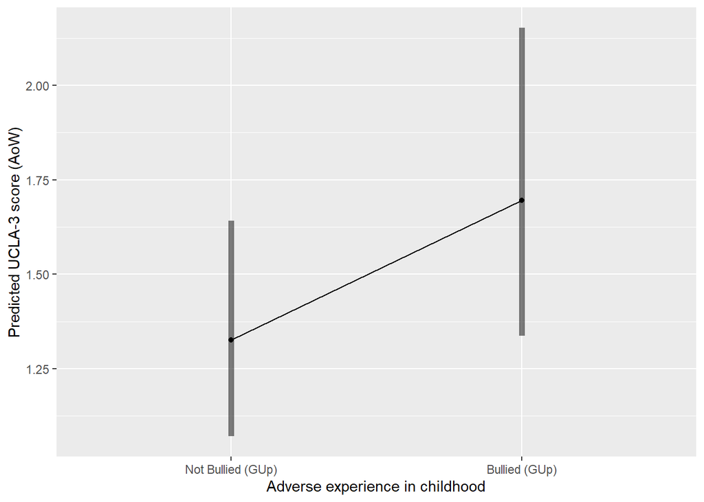

```r
emmip(lone_bully_poolmodel2, ~ GU_bullied_T1, CIs = T, type = "response",
    xlab = "Adverse experience in childhood", ylab = "Predicted UCLA-3 score (AoW)")
```

```r
ref_grid(lone_bully_poolmodel2) ## admincdobagemy_T0 = 28.078, hhd0tothhd_T0 = 4.6838, GU_AgeYears_T1 = 9.1518
```

```
## 'emmGrid' object with variables:
##     GU_bullied_T1 = Not Bullied (GUp), Bullied (GUp)
##     anyotherAE_exceptBullying_T0_T1 = No other AE, Other AE
##     admincgender_T0 = Male, Female
##     ethnicity5_C_T1 = White, Mixed, Asian, Black, Other
##     mbqlcasep5gp_T0 = Least dep and most educated, Employed not mat dep, Employed no access to money, Benefits but coping, Most dep
##     admincdobagemy_T0 = 28.078
##     hhd0tothhd_T0 = 4.6838
##     has_conganom_gp_T1_derived = No Record, Has congenital anomalies
##     GU_AgeYears_T1 = 9.1518
## Transformation: "log"
```

```r
# lone_bully_poolmodel3
lone_bully_poolmodel3 <- with(mice2662, glm.nb(loneliness0to6 ~ GU_bullied_T1 + anyotherAE_exceptBullying_T0_T1 + admincgender_T0 + ethnicity5_C_T1*mbqlcasep5gp_T0 + admincdobagemy_T0 + has_conganom_gp_T1_derived + hhd0tothhd_T0 + GU_AgeYears_T1))
lone_bully_pool3 <- pool(lone_bully_poolmodel3)
summary(lone_bully_pool3, conf.int=T, exponentiate=T)
```

```
##                                                               term    estimate
## 1                                                      (Intercept) 1.605540023
## 2                                       GU_bullied_T1Bullied (GUp) 1.276680852
## 3                          anyotherAE_exceptBullying_T0_T1Other AE 1.030438165
## 4                                            admincgender_T0Female 1.956275241
## 5                                             ethnicity5_C_T1Mixed 1.046207287
## 6                                             ethnicity5_C_T1Asian 0.875352249
## 7                                             ethnicity5_C_T1Black 0.969299467
## 8                                             ethnicity5_C_T1Other 1.003649532
## 9                              mbqlcasep5gp_T0Employed not mat dep 1.006283380
## 10                      mbqlcasep5gp_T0Employed no access to money 0.895628531
## 11                              mbqlcasep5gp_T0Benefits but coping 0.908916509
## 12                                         mbqlcasep5gp_T0Most dep 1.051821615
## 13                                               admincdobagemy_T0 0.987270022
## 14              has_conganom_gp_T1_derivedHas congenital anomalies 1.278521031
```

[output cut: 84 more lines]

```r
# Use modelsummary to tabulate model1-3
# **To use**
lone_bully_pooltab <- list("Univariate model (Model 1)" = lone_bully_poolmodel1, # then to add in for other variables
                               "Full model (Model 2)" = lone_bully_poolmodel2,
                               "Full model with interaction (Model 3)" = lone_bully_poolmodel3)
modelsummary(lone_bully_pooltab, estimate = "{estimate} [{conf.low}, {conf.high}]", statistic = NULL, exponentiate = T, coef_omit = "Intercept", coef_rename = coeff_name, gof_omit = "Log.Lik.|RMSE|F|Std.Errors")
```

|  | Univariate model (Model 1) | Full model (Model 2) | Full model with interaction (Model 3) |
| --- | --- | --- | --- |
| Was bullied vs not bullied (GUp) | 1.273 [1.106, 1.464] | 1.279 [1.110, 1.474] | 1.277 [1.107, 1.472] |
| anyotherAE_exceptBullying_T0_T1Other AE |  | 1.026 [0.896, 1.174] | 1.030 [0.900, 1.179] |
| Sex at birth (Female vs Male) |  | 1.948 [1.719, 2.208] | 1.956 [1.726, 2.217] |
| Mixed vs White adolescents |  | 0.820 [0.550, 1.222] | 1.046 [0.339, 3.227] |
| Asian vs White adolescents |  | 0.859 [0.720, 1.025] | 0.875 [0.598, 1.282] |
| Black vs White adolescents |  | 1.134 [0.622, 2.065] | 0.969 [0.344, 2.732] |
| Other vs White adolescents |  | 1.036 [0.636, 1.689] | 1.004 [0.374, 2.695] |
| Mother employed, not materially deprived vs least deprived and most educated (at baseline) |  | 0.996 [0.802, 1.237] | 1.006 [0.677, 1.495] |
| Mother employed, no access to money vs least deprived and most educated (at baseline) |  | 0.955 [0.771, 1.182] | 0.896 [0.564, 1.421] |
| Mother received benefits and not materially deprived vs least deprived and most educated (at baseline) |  | 0.906 [0.748, 1.097] | 0.909 [0.542, 1.525] |
| Mother most economically deprived vs least deprived and most educated (at baseline) |  | 0.935 [0.741, 1.181] | 1.052 [0.669, 1.653] |
| Mother's age (baseline) |  | 0.987 [0.975, 0.999] | 0.987 [0.975, 0.999] |
| Number of people in mother's household (baseline) |  | 0.987 [0.958, 1.017] | 0.987 [0.958, 1.017] |
| Has congenital anomalies vs no anomalies |  | 1.284 [0.995, 1.658] | 1.279 [0.990, 1.651] |
| Age at GUp survey |  | 0.979 [0.922, 1.040] | 0.981 [0.923, 1.042] |
| Mixed vs White adolescents:Mother employed, not materially deprived vs least deprived and most educated (at baseline) |  |  | 0.723 [0.158, 3.308] |
| Asian vs White adolescents:Mother employed, not materially deprived vs least deprived and most educated (at baseline) |  |  | 1.012 [0.617, 1.659] |
| Black vs White adolescents:Mother employed, not materially deprived vs least deprived and most educated (at baseline) |  |  | 0.002 [0.000, ] |
| Other vs White adolescents:Mother employed, not materially deprived vs least deprived and most educated (at baseline) |  |  | 0.500 [0.047, 5.363] |
| Mixed vs White adolescents:Mother employed, no access to money vs least deprived and most educated (at baseline) |  |  | 1.163 [0.272, 4.969] |
| Asian vs White adolescents:Mother employed, no access to money vs least deprived and most educated (at baseline) |  |  | 1.073 [0.626, 1.839] |
| Black vs White adolescents:Mother employed, no access to money vs least deprived and most educated (at baseline) |  |  | 1.238 [0.226, 6.784] |
| Other vs White adolescents:Mother employed, no access to money vs least deprived and most educated (at baseline) |  |  | 1.138 [0.245, 5.292] |
| Mixed vs White adolescents:Mother received benefits and not materially deprived vs least deprived and most educated (at baseline) |  |  | 0.679 [0.134, 3.425] |
| Asian vs White adolescents:Mother received benefits and not materially deprived vs least deprived and most educated (at baseline) |  |  | 0.996 [0.572, 1.736] |
| Black vs White adolescents:Mother received benefits and not materially deprived vs least deprived and most educated (at baseline) |  |  | 1.533 [0.210, 11.205] |
| Other vs White adolescents:Mother received benefits and not materially deprived vs least deprived and most educated (at baseline) |  |  | 0.910 [0.185, 4.470] |
| Mixed vs White adolescents:Mother most economically deprived vs least deprived and most educated (at baseline) |  |  | 0.549 [0.131, 2.297] |
| Asian vs White adolescents:Mother most economically deprived vs least deprived and most educated (at baseline) |  |  | 0.846 [0.497, 1.440] |
| Black vs White adolescents:Mother most economically deprived vs least deprived and most educated (at baseline) |  |  | 1.377 [0.276, 6.874] |
| Other vs White adolescents:Mother most economically deprived vs least deprived and most educated (at baseline) |  |  | 1.382 [0.300, 6.364] |

```r
#(to save) modelsummary(lone_bully_pooltab, estimate = "{estimate} [{conf.low}, {conf.high}]", statistic = NULL, exponentiate = T, coef_omit = "Intercept", coef_rename = coeff_name, gof_omit = "Log.Lik.|RMSE|F|Std.Errors", output = "lone_bully_pooltab.docx")

# E-Value using the stimulated adjusted OR from lone_bully_poolmodel2
evalues.OR(est = 1.2789947, 1.1099859, 1.4737371, rare = F) ## 1.515723 [1.291103, NA]
```

```
##             point    lower    upper
## RR       1.130926 1.053559 1.213976
## E-values 1.515723 1.291103       NA
```

```r
rm(lone_bully_pool1)
rm(lone_bully_pool3)
rm(lone_bully_pooltab)
rm(lone_bully_poolmodel1)
rm(lone_bully_poolmodel3)
```

```r
# Imputed: using pooled values of all 50 imputed datasets in mice2662_complete
lone_bully_poolmodel2_means <- emmeans(lone_bully_poolmodel2, revpairwise ~ GU_bullied_T1)

nblone_bully_model2_effecsize <- glm.nb(loneliness0to6 ~ GU_bullied_T1 + anyotherAE_exceptBullying_T0_T1 +
    admincgender_T0 + ethnicity5_C_T1 + mbqlcasep5gp_T0 + admincdobagemy_T0 + hhd0tothhd_T0 +
    has_conganom_gp_T1_derived + GU_AgeYears_T1, data = mice2662_complete)

eff_size(lone_bully_poolmodel2_means, sigma = sigma(nblone_bully_model2_effecsize),
    edf = df.residual(nblone_bully_model2_effecsize))  ## 0.246**
```

```
## Since 'object' is a list, we are using the contrasts already present.
```

```
##  contrast                            effect.size     SE   df lower.CL upper.CL
##  (Bullied (GUp) - Not Bullied (GUp))       0.246 0.0723 1057    0.104    0.388
##
## Results are averaged over the levels of: anyotherAE_exceptBullying_T0_T1, admincgender_T0, ethnicity5_C_T1, mbqlcasep5gp_T0, has_conganom_gp_T1_derived
## sigma used for effect sizes: 1
## Confidence level used: 0.95
```

```r
rm(lone_bully_poolmodel2_means, nblone_bully_model2_compcase_means, nblone_bully_model2_compcase,
    lone_bully_poolmodel2, lone_bully_pool2, nblone_bully_model2_effecsize, pooled_sd,
    cohens_d)
```

## Bullying MCSIMEX

For Model 2 of complete case analysis only, following Pina-Sánchez, J. and Varela, A. (2023). Adjusting for Random Measurement Error and Misclassification Using SIMEX. CrimRxiv. doi: https://doi.org/10.21428/cb6ab371.5ee05b65. [Accessed 4 January 2024].

The two value sets for the assumed misclassification in bullying.

```r
# Scenario 1: If the proportion of primary school children who were bullied was
# 52.7%, as found in the BiB Primary School Study, which asked children, an
# average age of 9, to self-report how often they were bullied (Pickett et al.,
# 2022).

# True Positive = 642 False Negative = (2606*0.527)-642 = 731 True Negative =
# (2606-642-731)*0.99 = 1220 False Negative rate = 731/(731+642)= 0.5325340**,
# hence sensitivity =1-0.5325340 = 0.4674660**

# using MC-SIMEX (Misclassification SIMEX, mcsimex) to adjust for
# misclassification in exposure (lived with both parents or not) X=0 X=1 X*=0
# 'Specificity' 'False negative rate' X*=1 'False positive rate' 'Sensitivity'
# Specifying the misclassification matrix T0.
bully_misclass <- matrix(c(0.99, 0.01, 0.532534, 0.467466), nrow = 2)
# To run mcsimex we need the same labels from the misclassified factor used as
# row and column labels in the misclassification matrix
dimnames(bully_misclass) <- list(levels(df2662_complcase$GU_bullied_T1), levels(df2662_complcase$GU_bullied_T1))
check.mc.matrix(list(bully_misclass))  ## True
```

```
## [1] TRUE
```

```r
# check that we got the misclassification matrix that we wanted.
bully_misclass
```

```
##                   Not Bullied (GUp) Bullied (GUp)
## Not Bullied (GUp)              0.99      0.532534
## Bullied (GUp)                  0.01      0.467466
```

```r
# Living with both parents or not on self-harm
sh_bully_model2_mice <- glm(awb2_9_seek_hurt_self_a5 ~ GU_bullied_T1, family = binomial("logit"),
    data = mice2662_complete, x = TRUE)

set.seed(8181)
# (to run**) sh_bully_misclass2simex <- mcsimex(sh_bully_model2_mice, mc.matrix
# = bully_misclass, SIMEXvariable = 'GU_bullied_T1', jackknife.estimation =
# FALSE)
summary(sh_bully_misclass2simex)
```

```
## Call:
## mcsimex(model = sh_bully_model2_mice, SIMEXvariable = "GU_bullied_T1",
##     mc.matrix = bully_misclass, jackknife.estimation = FALSE)
##
## Naive model:
## glm(formula = awb2_9_seek_hurt_self_a5 ~ GU_bullied_T1, family = binomial("logit"),
##     data = mice2662_complete, x = TRUE)
##
## Simex variable : GU_bullied_T1
## Misclassification matrix:
##                   Not Bullied (GUp) Bullied (GUp)
## Not Bullied (GUp)              0.99      0.532534
## Bullied (GUp)                  0.01      0.467466
##
## Number of iterations:  100
##
## Residuals:
##    Min. 1st Qu.  Median    Mean 3rd Qu.    Max.    NA's
##      NA      NA      NA     NaN      NA      NA    2662
##
## Coefficients:
##
## Asymptotic variance:
##                            Estimate Std. Error t value Pr(>|t|)
## (Intercept)                 -2.2408     0.1012 -22.145   <2e-16 ***
## GU_bullied_T1Bullied (GUp)   0.5318     0.1771   3.003   0.0027 **
## ---
## Signif. codes:  0 '***' 0.001 '**' 0.01 '*' 0.05 '.' 0.1 ' ' 1
```

```r
round(exp(cbind(OR = coef(sh_bully_misclass2simex), confint(sh_bully_misclass2simex))),
    3)  ## 1.702 [1.203, 2.408]
```

```
##                               OR 2.5 % 97.5 %
## (Intercept)                0.106 0.087  0.130
## GU_bullied_T1Bullied (GUp) 1.702 1.203  2.408
```

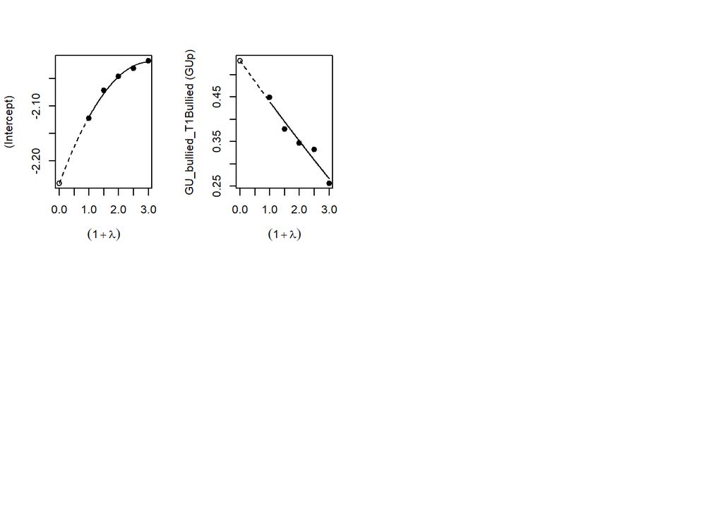

```r
plot(sh_bully_misclass2simex, mfrow = c(2, 4))
```

```r
rm(sh_bully_model2_mice)
```

```r
# Living with both parents or not on SWEMWBS (works with glm() but not lm())
swemwbs_bully_model2_mice_glm <- glm(swemwbs_sum_scaled ~ GU_bullied_T1, data = mice2662_complete,
    family = "gaussian", x = TRUE)

set.seed(8181)
# (to run*) swemwbs_bully_misclass2simex <-
# mcsimex(swemwbs_bully_model2_mice_glm, mc.matrix = bully_misclass,
# SIMEXvariable = 'GU_bullied_T1', jackknife.estimation = FALSE)
summary(swemwbs_bully_misclass2simex)
```

```
## Call:
## mcsimex(model = swemwbs_bully_model2_mice_glm, SIMEXvariable = "GU_bullied_T1",
##     mc.matrix = bully_misclass, jackknife.estimation = FALSE)
##
## Naive model:
## glm(formula = swemwbs_sum_scaled ~ GU_bullied_T1, family = "gaussian",
##     data = mice2662_complete, x = TRUE)
##
## Simex variable : GU_bullied_T1
## Misclassification matrix:
##                   Not Bullied (GUp) Bullied (GUp)
## Not Bullied (GUp)              0.99      0.532534
## Bullied (GUp)                  0.01      0.467466
##
## Number of iterations:  100
##
## Residuals:
##     Min.  1st Qu.   Median     Mean  3rd Qu.     Max.
## -14.5056  -2.9156  -0.6979  -0.1014   2.5321  14.3221
##
## Coefficients:
##
## Asymptotic variance:
##                            Estimate Std. Error t value Pr(>|t|)
## (Intercept)                 21.5056     0.1267 169.726  < 2e-16 ***
## GU_bullied_T1Bullied (GUp)  -0.8277     0.2532  -3.269  0.00109 **
## ---
## Signif. codes:  0 '***' 0.001 '**' 0.01 '*' 0.05 '.' 0.1 ' ' 1
```

```r
round(cbind(est = coef(swemwbs_bully_misclass2simex), confint(swemwbs_bully_misclass2simex)),
    3)  ## -0.828 [-1.324, -0.331]
```

```
##                               est  2.5 % 97.5 %
## (Intercept)                21.506 21.257 21.754
## GU_bullied_T1Bullied (GUp) -0.828 -1.324 -0.331
```

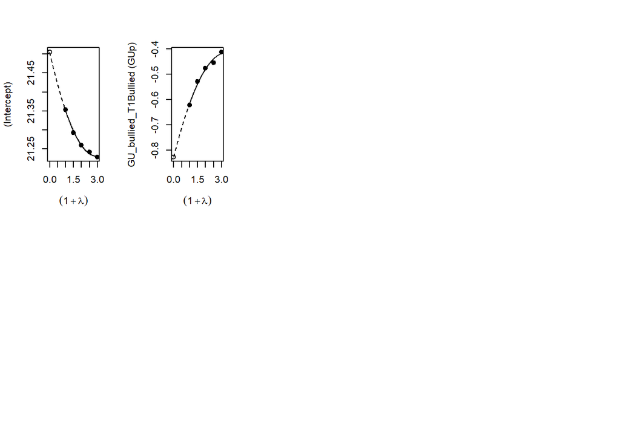

```r
plot(swemwbs_bully_misclass2simex, mfrow = c(2, 5))
```

```r
rm(swemwbs_bully_model2_mice_glm)
```

```r
# Living with both parents or not on RCADS-25
rcads_bully_model2_mice <- glm(rcad_total_t ~ GU_bullied_T1, family = Gamma(link = "identity"),
    data = mice2662_complete, x = TRUE)

set.seed(8181)
# (to run*) rcads_bully_misclass2simex <- mcsimex(rcads_bully_model2_mice,
# mc.matrix = bully_misclass, SIMEXvariable = 'GU_bullied_T1',
# jackknife.estimation = FALSE)
summary(rcads_bully_misclass2simex)
```

```
## Call:
## mcsimex(model = rcads_bully_model2_mice, SIMEXvariable = "GU_bullied_T1",
##     mc.matrix = bully_misclass, jackknife.estimation = FALSE)
##
## Naive model:
## glm(formula = rcad_total_t ~ GU_bullied_T1, family = Gamma(link = "identity"),
##     data = mice2662_complete, x = TRUE)
##
## Simex variable : GU_bullied_T1
## Misclassification matrix:
##                   Not Bullied (GUp) Bullied (GUp)
## Not Bullied (GUp)              0.99      0.532534
## Bullied (GUp)                  0.01      0.467466
##
## Number of iterations:  100
##
## Residuals:
##    Min. 1st Qu.  Median    Mean 3rd Qu.    Max.
## -23.740 -10.805  -2.506   0.576   8.709  70.957
##
## Coefficients:
##
## Asymptotic variance:
##                            Estimate Std. Error t value Pr(>|t|)
## (Intercept)                 46.8653     0.4450 105.306  < 2e-16 ***
## GU_bullied_T1Bullied (GUp)   4.0973     0.9437   4.342 1.47e-05 ***
## ---
## Signif. codes:  0 '***' 0.001 '**' 0.01 '*' 0.05 '.' 0.1 ' ' 1
```

```r
round(cbind(est = coef(rcads_bully_misclass2simex), confint(rcads_bully_misclass2simex)),
    3)  ## 4.097 [2.248, 5.947]
```

```
##                               est  2.5 % 97.5 %
## (Intercept)                46.865 45.993 47.738
## GU_bullied_T1Bullied (GUp)  4.097  2.248  5.947
```

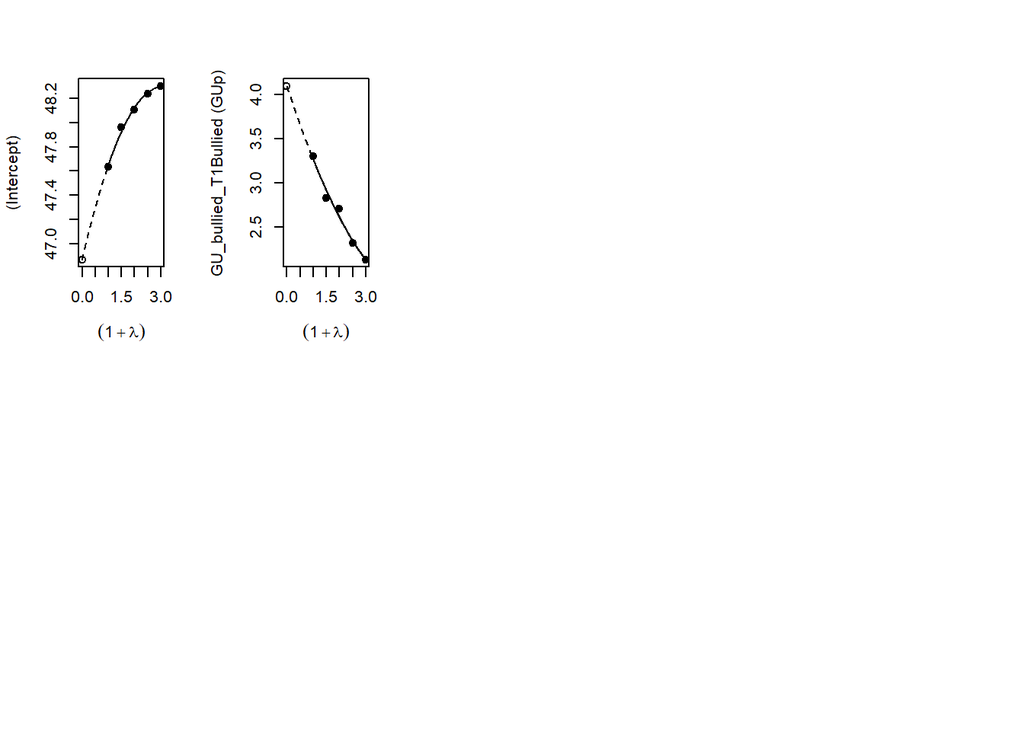

```r
plot(rcads_bully_misclass2simex, mfrow = c(2, 5))
```

```r
rm(rcads_bully_model2_mice)
```

```r
# Living with both parents or not on loneliness
nblone_bully_model2_mice <- glm.nb(loneliness0to6 ~ GU_bullied_T1, data = mice2662_complete,
    x = TRUE)

set.seed(8181)
# (To run**) lone_bully_misclass2simex <- mcsimex(nblone_bully_model2_mice,
# mc.matrix = bully_misclass, SIMEXvariable = 'GU_bullied_T1',
# jackknife.estimation = FALSE)
summary(lone_bully_misclass2simex)
```

```
## Call:
## mcsimex(model = nblone_bully_model2_mice, SIMEXvariable = "GU_bullied_T1",
##     mc.matrix = bully_misclass, jackknife.estimation = FALSE)
##
## Naive model:
## glm.nb(formula = loneliness0to6 ~ GU_bullied_T1, data = mice2662_complete,
##     x = TRUE, init.theta = 0.7651994298, link = log)
##
## Simex variable : GU_bullied_T1
## Misclassification matrix:
##                   Not Bullied (GUp) Bullied (GUp)
## Not Bullied (GUp)              0.99      0.532534
## Bullied (GUp)                  0.01      0.467466
##
## Number of iterations:  100
##
## Residuals:
##     Min.  1st Qu.   Median     Mean  3rd Qu.     Max.
## -1.46632 -1.12342 -1.12342  0.05931  0.87658  4.87658
##
## Coefficients:
##
## Asymptotic variance:
##                            Estimate Std. Error t value Pr(>|t|)
## (Intercept)                 0.11638    0.04074   2.857 0.004315 **
## GU_bullied_T1Bullied (GUp)  0.26638    0.07404   3.598 0.000327 ***
## ---
## Signif. codes:  0 '***' 0.001 '**' 0.01 '*' 0.05 '.' 0.1 ' ' 1
```

```r
round(exp(cbind(ratio = coef(lone_bully_misclass2simex), confint(lone_bully_misclass2simex))),
    3)  ## 1.305 [1.129, 1.509]
```

```
##                            ratio 2.5 % 97.5 %
## (Intercept)                1.123 1.037  1.217
## GU_bullied_T1Bullied (GUp) 1.305 1.129  1.509
```

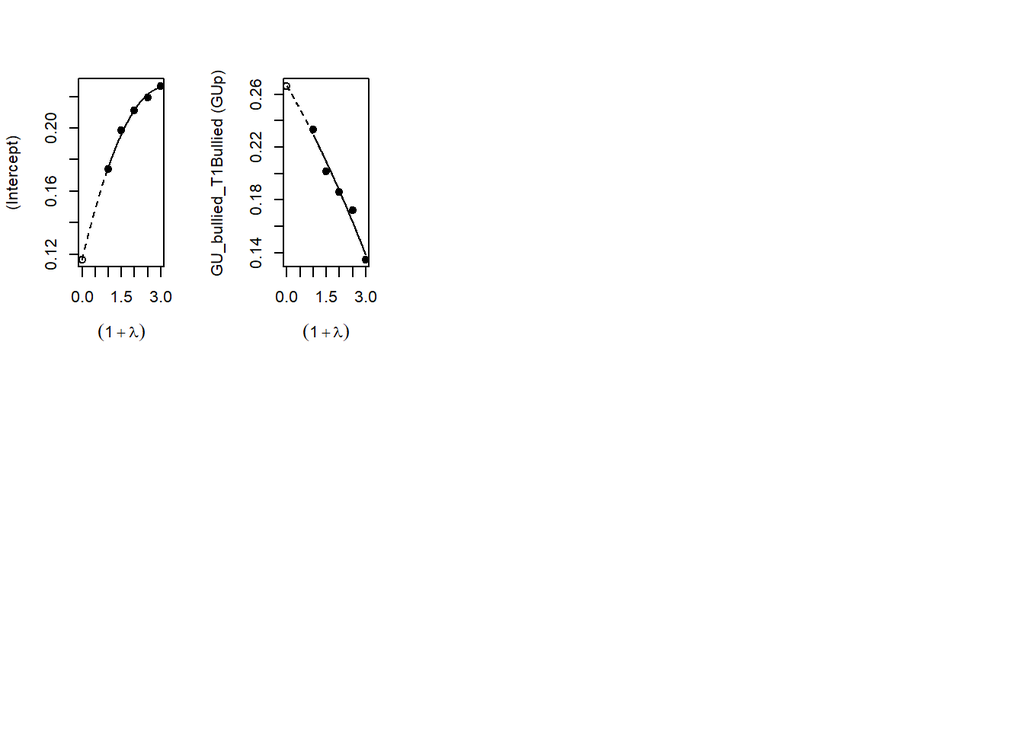

```r
plot(lone_bully_misclass2simex, mfrow = c(2, 5))
```

```r
rm(nblone_bully_model2_mice)
```

## Parental substance use on self-harm

awb2_9_seek_hurt_self_a5 ~ anyAlcSubProbT0_T1 admincgender_T0 ethnicity5_C_T1 mbqlcasep5gp_T0 admincdobagemy_T0 has_conganom_gp_T1_derived hhd0tothhd_T0 GU_AgeYears_T1_derived anyotherAE_exceptSubProb_T0_T1 ethnicity5_C_T1 : mbqlcasep5gp_T0

```r
# Complete case (n=1603)
sh_sub_unadjcompcase <- glm(awb2_9_seek_hurt_self_a5 ~ anyAlcSubProbT0_T1, family = binomial("logit"),
    data = df2662_complcase)
summ(sh_sub_unadjcompcase)
```

| Observations | 1603 (1059 missing obs. deleted) |
| --- | --- |
| Dependent variable | awb2_9_seek_hurt_self_a5 |
| Type | Generalized linear model |
| Family | binomial |
| Link | logit |

| χ²(1) | 3.63 |
| --- | --- |
| p | 0.06 |
| Pseudo-R² (Cragg-Uhler) | 0.00 |
| Pseudo-R² (McFadden) | 0.00 |
| AIC | 1450.75 |
| BIC | 1461.51 |

|  | Est. | S.E. | z val. | p |
| --- | --- | --- | --- | --- |
| (Intercept) | -1.64 | 0.07 | -23.46 | 0.00 |
| anyAlcSubProbT0_T1Parental Sub Use | 0.49 | 0.25 | 1.98 | 0.05 |

Standard errors: MLE

```r
# Predicted probabilities of self-harm
emmeans(sh_sub_unadjcompcase, revpairwise ~ anyAlcSubProbT0_T1, type = "response",
    infer = T)
```

```
## $emmeans
##  anyAlcSubProbT0_T1   prob      SE  df asymp.LCL asymp.UCL null z.ratio p.value
##  No parental Sub Use 0.163 0.00951 Inf     0.145     0.183  0.5 -23.461  <.0001
##  Parental Sub Use    0.242 0.04390 Inf     0.167     0.338  0.5  -4.765  <.0001
##
## Confidence level used: 0.95
## Intervals are back-transformed from the logit scale
## Tests are performed on the logit scale
##
## $contrasts
##  contrast                               odds.ratio    SE  df asymp.LCL
##  Parental Sub Use / No parental Sub Use       1.64 0.409 Inf      1.01
##  asymp.UCL null z.ratio p.value
##       2.67    1   1.980  0.0477
##
## Confidence level used: 0.95
## Intervals are back-transformed from the log odds ratio scale
## Tests are performed on the log odds ratio scale
```

```r
# stratify by living with both parents or not, using mean values of the 50
# imputed datasets
sh_sub_home_2parents <- glm(awb2_9_seek_hurt_self_a5 ~ anyAlcSubProbT0_T1, family = binomial("logit"),
    data = mice2662_complete, subset = anyNotlivewithMFT0_T1 == "No")  ## 2 parents OR 1.936 [1.087, 3.268]
round(exp(cbind(OR = coef(sh_sub_home_2parents), confint(sh_sub_home_2parents))),
    3)
```

```
##                                       OR 2.5 % 97.5 %
## (Intercept)                        0.124 0.107  0.142
## anyAlcSubProbT0_T1Parental Sub Use 1.936 1.087  3.268
```

```r
sh_sub_home_1parent <- glm(awb2_9_seek_hurt_self_a5 ~ anyAlcSubProbT0_T1, family = binomial("logit"),
    data = mice2662_complete, subset = anyNotlivewithMFT0_T1 == "Yes")  ## <=1parent= 1.239 [0.589, 2.405]
round(exp(cbind(Or = coef(sh_sub_home_1parent), confint(sh_sub_home_1parent))), 3)
```

```
##                                       Or 2.5 % 97.5 %
## (Intercept)                        0.161 0.124  0.207
## anyAlcSubProbT0_T1Parental Sub Use 1.239 0.589  2.405
```

```r
# complete case of parental substance use GP records only
sh_sub_unadj_compcase_record <- glm(awb2_9_seek_hurt_self_a5 ~ anyAlcSubrecordT0_T1,
    family = binomial("logit"), data = df2662)
summ(sh_sub_unadj_compcase_record)  ## OR 0.643 [0.152, 1.864] (p=0.47) (n=1603), very imprecise estimate.
```

| Observations | 1603 (1059 missing obs. deleted) |
| --- | --- |
| Dependent variable | awb2_9_seek_hurt_self_a5 |
| Type | Generalized linear model |
| Family | binomial |
| Link | logit |

| χ²(1) | 0.57 |
| --- | --- |
| p | 0.45 |
| Pseudo-R² (Cragg-Uhler) | 0.00 |
| Pseudo-R² (McFadden) | 0.00 |
| AIC | 1453.81 |
| BIC | 1464.57 |

|  | Est. | S.E. | z val. | p |
| --- | --- | --- | --- | --- |
| (Intercept) | -1.60 | 0.07 | -23.72 | 0.00 |
| anyAlcSubrecordT0_T1Yes | -0.44 | 0.62 | -0.72 | 0.47 |

Standard errors: MLE

```r
round(exp(cbind(OR = coef(sh_sub_unadj_compcase_record), confint(sh_sub_unadj_compcase_record))),
    3)
```

```
##                            OR 2.5 % 97.5 %
## (Intercept)             0.203 0.177  0.231
## anyAlcSubrecordT0_T1Yes 0.643 0.152  1.864
```

```r
# mothers with substance use GP records (n=20)
sh_sub_unadj_compcase_record_M <- glm(awb2_9_seek_hurt_self_a5 ~ anyAlcSubrecord_M_T0_T1,
    family = binomial("logit"), data = df2662)
summ(sh_sub_unadj_compcase_record_M)  ## OR 1.660 [0.367, 5.607] (p=0.45) (n=1603)
```

| Observations | 1603 (1059 missing obs. deleted) |
| --- | --- |
| Dependent variable | awb2_9_seek_hurt_self_a5 |
| Type | Generalized linear model |
| Family | binomial |
| Link | logit |

| χ²(1) | 0.52 |
| --- | --- |
| p | 0.47 |
| Pseudo-R² (Cragg-Uhler) | 0.00 |
| Pseudo-R² (McFadden) | 0.00 |
| AIC | 1453.86 |
| BIC | 1464.62 |

|  | Est. | S.E. | z val. | p |
| --- | --- | --- | --- | --- |
| (Intercept) | -1.61 | 0.07 | -23.90 | 0.00 |
| anyAlcSubrecord_M_T0_T1TRUE | 0.51 | 0.67 | 0.76 | 0.45 |

Standard errors: MLE

```r
round(exp(cbind(OR = coef(sh_sub_unadj_compcase_record_M), confint(sh_sub_unadj_compcase_record_M))),
    3)
```

```
##                                OR 2.5 % 97.5 %
## (Intercept)                 0.201 0.176  0.229
## anyAlcSubrecord_M_T0_T1TRUE 1.660 0.367  5.607
```

```r
# Fathers with substance use GP records (n=24)
df2662 %>%
    count(awb2_9_seek_hurt_self_a5, anyAlcSubrecord_F_T0_T1)  ## none reported, though missing n=10
```

```
## # A tibble: 5 × 3
##   awb2_9_seek_hurt_self_a5 anyAlcSubrecord_F_T0_T1     n
##   <fct>                    <lgl>                   <int>
## 1 No                       FALSE                    1320
## 2 No                       TRUE                       14
## 3 Yes                      FALSE                     269
## 4 <NA>                     FALSE                    1049
## 5 <NA>                     TRUE                       10
```

```r
# complete case of parental substance use survey only
sh_sub_unadj_compcase_mumalc <- glm(awb2_9_seek_hurt_self_a5 ~ AlcoProblem_M_T1,
    family = binomial("logit"), data = df2662)
summ(sh_sub_unadj_compcase_mumalc)  ## OR 1.461 [0.747, 2.671] (p=0.24) (n=1572)
```

| Observations | 1572 (1090 missing obs. deleted) |
| --- | --- |
| Dependent variable | awb2_9_seek_hurt_self_a5 |
| Type | Generalized linear model |
| Family | binomial |
| Link | logit |

| χ²(1) | 1.29 |
| --- | --- |
| p | 0.26 |
| Pseudo-R² (Cragg-Uhler) | 0.00 |
| Pseudo-R² (McFadden) | 0.00 |
| AIC | 1422.49 |
| BIC | 1433.21 |

|  | Est. | S.E. | z val. | p |
| --- | --- | --- | --- | --- |
| (Intercept) | -1.62 | 0.07 | -23.41 | 0.00 |
| AlcoProblem_M_T1Possibly | 0.38 | 0.32 | 1.18 | 0.24 |

Standard errors: MLE

```r
round(exp(cbind(OR = coef(sh_sub_unadj_compcase_mumalc), confint(sh_sub_unadj_compcase_mumalc))),
    3)
```

```
##                             OR 2.5 % 97.5 %
## (Intercept)              0.198 0.172  0.226
## AlcoProblem_M_T1Possibly 1.461 0.747  2.671
```

```r
sh_sub_unadj_compcase_dadalc <- glm(awb2_9_seek_hurt_self_a5 ~ AlcoProblem_F_T1,
    family = binomial("logit"), data = df2662)
summ(sh_sub_unadj_compcase_dadalc)  ## OR 1.746 [0.418, 6.500] (p=0.41) (n=84)
```

| Observations | 84 (2578 missing obs. deleted) |
| --- | --- |
| Dependent variable | awb2_9_seek_hurt_self_a5 |
| Type | Generalized linear model |
| Family | binomial |
| Link | logit |

| χ²(1) | 0.64 |
| --- | --- |
| p | 0.42 |
| Pseudo-R² (Cragg-Uhler) | 0.01 |
| Pseudo-R² (McFadden) | 0.01 |
| AIC | 99.97 |
| BIC | 104.83 |

|  | Est. | S.E. | z val. | p |
| --- | --- | --- | --- | --- |
| (Intercept) | -1.12 | 0.27 | -4.11 | 0.00 |
| AlcoProblem_F_T1Possibly | 0.56 | 0.68 | 0.82 | 0.41 |

Standard errors: MLE

```r
round(exp(cbind(OR = coef(sh_sub_unadj_compcase_dadalc), confint(sh_sub_unadj_compcase_dadalc))),
    3)
```

```
##                             OR 2.5 % 97.5 %
## (Intercept)              0.327 0.187  0.546
## AlcoProblem_F_T1Possibly 1.746 0.418  6.500
```

```r
rm(sh_sub_unadj_compcase_dadalc, sh_sub_unadj_compcase_mumalc, sh_sub_unadj_compcase_record,
    sh_sub_home_2parents, sh_sub_home_1parent, sh_sub_unadj_compcase_record_M)
```

```r
# Complete case Model2 (n=1311)
sh_sub_model2_compcase <- glm(awb2_9_seek_hurt_self_a5 ~ anyAlcSubProbT0_T1 + anyotherAE_exceptSubProb_T0_T1 +
    admincgender_T0 + ethnicity5_C_T1 + mbqlcasep5gp_T0 + admincdobagemy_T0 + hhd0tothhd_T0 +
    has_conganom_gp_T1_derived + GU_AgeYears_T1_derived, family = binomial("logit"),
    data = df2662_complcase, x = TRUE)
summ(sh_sub_model2_compcase, vif = T)  # all VIFs<2
```

| Observations | 1311 (1351 missing obs. deleted) |
| --- | --- |
| Dependent variable | awb2_9_seek_hurt_self_a5 |
| Type | Generalized linear model |
| Family | binomial |
| Link | logit |

| χ²(15) | 51.58 |
| --- | --- |
| p | 0.00 |
| Pseudo-R² (Cragg-Uhler) | 0.06 |
| Pseudo-R² (McFadden) | 0.04 |
| AIC | 1172.99 |
| BIC | 1255.85 |

|  | Est. | S.E. | z val. | p | VIF |
| --- | --- | --- | --- | --- | --- |
| (Intercept) | -1.47 | 0.87 | -1.68 | 0.09 | NA |
| anyAlcSubProbT0_T1Parental Sub Use | 0.30 | 0.30 | 1.01 | 0.31 | 1.19 |
| anyotherAE_exceptSubProb_T0_T1Other AE | 0.48 | 0.16 | 2.97 | 0.00 | 1.07 |
| admincgender_T0Female | 0.91 | 0.16 | 5.55 | 0.00 | 1.03 |
| ethnicity5_C_T1Mixed | -0.45 | 0.45 | -0.98 | 0.32 | 1.59 |
| ethnicity5_C_T1Asian | -0.31 | 0.21 | -1.45 | 0.15 | 1.59 |
| ethnicity5_C_T1Black | 0.20 | 0.71 | 0.28 | 0.78 | 1.59 |
| ethnicity5_C_T1Other | -0.38 | 0.79 | -0.48 | 0.63 | 1.59 |
| mbqlcasep5gp_T0Employed not mat dep | -0.08 | 0.26 | -0.31 | 0.76 | 1.31 |
| mbqlcasep5gp_T0Employed no access to money | -0.17 | 0.25 | -0.68 | 0.50 | 1.31 |
| mbqlcasep5gp_T0Benefits but coping | -0.04 | 0.23 | -0.20 | 0.84 | 1.31 |
| mbqlcasep5gp_T0Most dep | -0.08 | 0.28 | -0.29 | 0.77 | 1.31 |
| admincdobagemy_T0 | -0.01 | 0.01 | -0.68 | 0.50 | 1.06 |
| hhd0tothhd_T0 | -0.04 | 0.04 | -1.16 | 0.24 | 1.25 |
| has_conganom_gp_T1_derivedHas congenital anomalies | 0.18 | 0.34 | 0.53 | 0.60 | 1.01 |
| GU_AgeYears_T1_derived | -0.03 | 0.07 | -0.36 | 0.72 | 1.01 |

Standard errors: MLE

```r
round(exp(cbind(OR = sh_sub_model2_compcase$coeff, confint(sh_sub_model2_compcase))),
    3) %>%
    kable()
```

|  | OR | 2.5 % | 97.5 % |
| --- | --- | --- | --- |
| (Intercept) | 0.230 | 0.041 | 1.272 |
| anyAlcSubProbT0_T1Parental Sub Use | 1.349 | 0.739 | 2.387 |
| anyotherAE_exceptSubProb_T0_T1Other AE | 1.622 | 1.183 | 2.238 |
| admincgender_T0Female | 2.489 | 1.813 | 3.453 |
| ethnicity5_C_T1Mixed | 0.640 | 0.244 | 1.482 |
| ethnicity5_C_T1Asian | 0.737 | 0.489 | 1.118 |
| ethnicity5_C_T1Black | 1.222 | 0.253 | 4.584 |
| ethnicity5_C_T1Other | 0.683 | 0.102 | 2.699 |
| mbqlcasep5gp_T0Employed not mat dep | 0.924 | 0.557 | 1.528 |
| mbqlcasep5gp_T0Employed no access to money | 0.844 | 0.515 | 1.378 |
| mbqlcasep5gp_T0Benefits but coping | 0.956 | 0.617 | 1.496 |
| mbqlcasep5gp_T0Most dep | 0.921 | 0.528 | 1.586 |
| admincdobagemy_T0 | 0.990 | 0.962 | 1.019 |
| hhd0tothhd_T0 | 0.959 | 0.893 | 1.028 |
| has_conganom_gp_T1_derivedHas congenital anomalies | 1.195 | 0.590 | 2.250 |
| GU_AgeYears_T1_derived | 0.975 | 0.847 | 1.122 |